# Derivation of Principal Component Analysis (PCA) and example using Wine data set

Ian Cairns

2023-08-31

# Intro

One of the goals of principal component analysis (PCA) is to reduce the original data set into a smaller set of *uncorrelated* linear combinations of our independent variables. PCA is particularly useful in data sets where multicollinearity exists in a multiple linear regression setting. Addressing multicollinearity helps improve the reliability of the regression model, making it a more valuable tool for understanding relationships between variables and making predictions (Alin 2010).

In this article, we shall derive the principal components mathematically and demonstrate this method with the `wine` data set from UCI’s machine learning lab (Aeberhard and Forina 1991).

# Derivation

Let $X = \left[ X_1, X_2, \dots, X_p \right]'$ have covariance matrix $\Sigma$, with eigenvalues $\lambda_1 \geq \lambda_2 \geq \dots \geq \lambda_p \geq 0$ and orthonormal eigenvectors $e_1, \dots, e_p$. Consider the linear combinations

$$Y_1 = a_1'X = a_{11}X_1 + a_{12}X_2 + \dots + a_{1p}X_p$$

$$Y_2 = a_2'X = a_{21}X_1 + a_{22}X_2 + \dots + a_{2p}X_p$$

$$\vdots$$

$$Y_p = a_p'X = a_{p1}X_1 + a_{p2}X_2 + \dots + a_{pp}X_p$$

Then, using properties of the variance operator we obtain

$$\text{Var}(Y_i) = a_i'\Sigma a_i \ i = 1,2,\dots,p$$

$$\text{Cov}(Y_i,Y_k) = a_i'\Sigma a_k \ i,k = 1,2,\dots,p$$

The principal components are those *uncorrelated* linear combinations $Y_1, Y_2, \dots, Y_p$ whose variances are as large as possible. The first principal component is the linear combination that maximizes $\text{Var}(Y_1) = a_1'\Sigma a_1$, and so forth for the remaining principal components. We shall restrict attention to coefficient vectors of unit length in order to avoid indeterminacy with scaling since $a_i$ could be scaled by any number.

As such, we shall maximize the following form:

$$\underset{a_i \neq 0}{\mathrm{argmax}}\frac{a_i'\Sigma
a_i}{a_i'a_i}$$

The maximization of quadratic forms lemma states: let $A_{p \times p}$ be a symmetric, and positive definite matrix with eigenvalues with eigenvalues $\lambda_1 \geq \lambda_2 \geq \dots \geq \lambda_p > 0$ and orthonormal eigenvectors $e_1, \dots, e_p$. Then

$$\underset{x\neq 0}{\mathrm{argmin}} \ \frac{x'Ax}{x'x} =
\lambda_p$$

and

$$\underset{x \perp e_1, e_2, \dots, e_k}{\mathrm{argmax}} \
\frac{x'Ax}{x'x} = \lambda_{k+1} \ \text{for} \ k=1,\dots,p-1$$

**Proof:**

$$A = P \Lambda P'$$

Where $P$ is a square $p \times p$ matrix whose $i$th column is the eigenvector $e_i$ of $A$ and $\Lambda$ is the diagonal matrix whose elements are the corresponding eigenvalues.

Let $y=P'x$, so that $x=Py$ therefore

$$\frac{x'Ax}{x'x} = \frac{x'P \Lambda P'x}{x'x} =
\frac{y'P'P \Lambda y}{y'P'Py} = \frac{y'P'P
\Lambda y}{y'P'Py} = \frac{y' \Lambda y}{y'y}$$

Since $P'P=I$. We shall first prove the first principal component has variance $\lambda_1$, so

$$\frac{y' \Lambda y}{y'y} = \frac{\sum_{i=1}^p
\lambda_iy_i^2}{\sum_{i=1}^p y_i^2} \leq \frac{\sum_{i=1}^p
\lambda_1y_i^2}{\sum_{i=1}^p y_i^2} = \lambda_1$$

Since $\lambda_1 \geq \lambda_2 \geq \dots \geq \lambda_p > 0$. Therefore the maximum is achieved when $x=e_1$ because

$$\frac{x'Ax}{x'x} = \frac{e_1'Ae_1}{e_1'e_1} =
\frac{e_1'\lambda_1e_1}{e_1'e_1} = \lambda_1$$

Since by the definition of eigenvalues and eigenvectors $Ae_i = \lambda_ie_i$. If we let $A = \Sigma$, $a_1 = e_1$, and remember our orthogonal eigenvectors have the property that $e_1'e_1 = 1$ then we get the following result

$$\underset{a_1 \neq 0}{\mathrm{argmax}} \ a_1'\Sigma a_1 =
\underset{a_1 \neq 0}{\mathrm{argmax}} \ \frac{a_1'\Sigma
a_1}{a_1'a_1} = \lambda_1$$

So the maximum variance is achieved at $\lambda_1$ and we have the coefficients for our linear combination based on the eigenvector $e_1$. The proof of minimum variance follows the same pattern but with $\lambda_1$ replaced with $\lambda_p$.

Now let $x \perp e_1, e_2, \dots, e_k$. Then $e_i x = 0$ for $i=1,\dots,k$. Using our definition that $x=Py$ we get the following result

$$0 = e_ix = e_i P y$$

$$e_i [e_1 | e_2 |\dots|e_p]y = [0,\dots,1,0,\dots,0][y_1,\dots,y_p]'$$

At the $i$th position. Therefore

$$= y_i$$

That is, $y_i = 0$ for $i=1,\dots,k$. So

$$\frac{x'Ax}{x'x} =
\frac{\sum_{i=1}^{p}\lambda_iy_i^2}{\sum_{i=1}^{p}y_i^2} =
\frac{\sum_{i=k+1}^{p}\lambda_iy_i^2}{\sum_{i=k+1}^{p}y_i^2} \leq
\frac{\sum_{i=k+1}^{p}\lambda_{k+1}y_i^2}{\sum_{i=k+1}^{p}y_i^2} =
\lambda_{k+1}$$

And equality (or maximum) is achieved when $x = e_{k+1}$ subject to $\text{Cov}(Y_i,Y_k)=0 \ \forall \ k<i$ $\square$.

So, the $i$th principal component is $Y_i=e_iX$ and $\text{Var}(Y_i)=\lambda_i$.

As a result we have

$$\sum_i^{p}\text{Var}(Y_i) = \sum_i^{p}\text{Var}(X_i)$$

**Proof:**

$$\sum_i^{p}\text{Var}(X_i) = \text{tr}\Sigma = \text{tr}(P\Lambda P')
= \text{tr}(P'P\Lambda) = \text{tr}(\Lambda) = \sum_i^{p}\lambda_i =
\sum_i^{p}\text{Var}(Y_i)$$

By the cyclic property of trace. Therefore the proportion of total variance explained by the $i$th principal component is

$$\frac{\lambda_i}{ \sum_i^{p}\lambda_i}$$

If most (for instance, 80 to 90%) of the total population variance, for large p, can be attributed to the first one, two, or three components, then these components can “replace” the original p variables without much loss of information (Johnson and Wichern 2007).

A useful visual aid in determining the appropriate number of principal components is a scree plot and viewing at which number of principal components a bend, or elbow, appears. This indicates at a certain point, there is not much variability contributing from the remaining principal components.

Note: The previous derivations were done assuming the population variance-covariance matrix, $\Sigma$ was known, which may not always be the case. Regardless, the derivations can still be completed using the sample variance-covariance matrix $S$ in place of $\Sigma$ for the same results.

# Example of PCA

```r
library(ggplot2)
library(reshape2)
library(knitr)
```

```r
wine_data <- read.csv("wine.data")
colnames(wine_data) <- c("Class", "Alcohol", "Malic", "Ash", "Alcalinity", "Magnesium", "Phenols", "Flavanoids", "Nonflavanoid", "Proanthocyanins", "ColorIntensity", "Hue", "OD280_OD315", "Proline")
wine_data <- scale(wine_data[,-1])
kable(wine_data[1:10,])
```

| Alcohol | Malic | Ash | Alcalinity | Magnesium | Phenols | Flavanoids | Nonflavanoid | Proanthocyanins | ColorIntensity | Hue | OD280_OD315 | Proline |
| --- | --- | --- | --- | --- | --- | --- | --- | --- | --- | --- | --- | --- |
| 0.2551008 | -0.5002053 | -0.8221529 | -2.4930372 | 0.0290976 | 0.5710456 | 0.7375437 | -0.8208101 | -0.5370519 | -0.2903066 | 0.4059482 | 1.1284966 | 0.9683055 |
| 0.2056453 | 0.0179690 | 1.1045562 | -0.2748590 | 0.0996492 | 0.8104843 | 1.2181890 | -0.4999191 | 2.1399040 | 0.2689663 | 0.3186634 | 0.8023031 | 1.3970348 |
| 1.7016732 | -0.3483266 | 0.4865552 | -0.8144158 | 0.9462687 | 2.4865554 | 1.4685250 | -0.9812556 | 1.0376281 | 1.1810114 | -0.4232572 | 1.1994082 | 2.3338876 |
| 0.3045563 | 0.2234520 | 1.8316163 | 0.4445501 | 1.2990268 | 0.8104843 | 0.6674496 | 0.2220856 | 0.4077561 | -0.3161192 | 0.3623058 | 0.4619272 | -0.0320627 |
| 1.4914875 | -0.5180734 | 0.3047901 | -1.2940219 | 0.8757170 | 1.5607256 | 1.3683906 | -0.1790282 | 0.6702028 | 0.7292910 | 0.4059482 | 0.3484686 | 2.2386144 |
| 1.7264010 | -0.4197989 | 0.3047901 | -1.4738742 | -0.2531089 | 0.3316069 | 0.4972211 | -0.4999191 | 0.6876992 | 0.0839760 | 0.2750210 | 1.3837785 | 1.7304908 |
| 1.3183934 | -0.1696458 | 0.8864382 | -0.5746128 | 1.5106816 | 0.4912327 | 0.4872077 | -0.4196964 | -0.5895412 | -0.0020660 | 0.4495905 | 1.3837785 | 1.7463697 |
| 2.2704111 | -0.6252819 | -0.7130939 | -1.6537265 | -0.1825573 | 0.8104843 | 0.9578395 | -0.5801419 | 0.6876992 | 0.0624655 | 0.5368753 | 0.3484686 | 0.9524266 |
| 1.0711160 | -0.8843690 | -0.3495639 | -1.0542189 | -0.1120057 | 1.0978108 | 1.1280680 | -1.1417010 | 0.4602454 | 0.9314896 | 0.2313786 | 1.3412315 | 0.9524266 |
| 1.3678488 | -0.1607118 | -0.2405049 | -0.4547113 | 0.3818557 | 1.0499230 | 1.2982965 | -1.1417010 | 1.3875569 | 0.2990810 | 1.2787959 | 0.8023031 | 2.4291607 |

The data set contains $13$ variables that contribute to identifying a type of wine, called `class`(1-3).

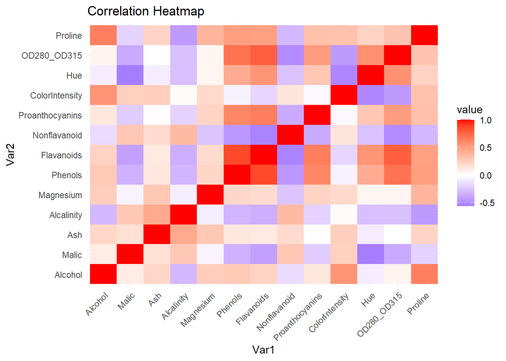

```r
correlation_matrix <- cor(wine_data)
ggplot(data = melt(correlation_matrix), aes(x=Var1, y=Var2, fill=value)) +
  geom_tile() +
  scale_fill_gradient2(low = "blue", mid = "white", high = "red", midpoint = 0) +
  theme_minimal() +
  theme(axis.text.x = element_text(angle = 45, hjust = 1)) +
  labs(title = "Correlation Heatmap")
```

The high correlation among some of the predictors suggests that multicollinearity exists.

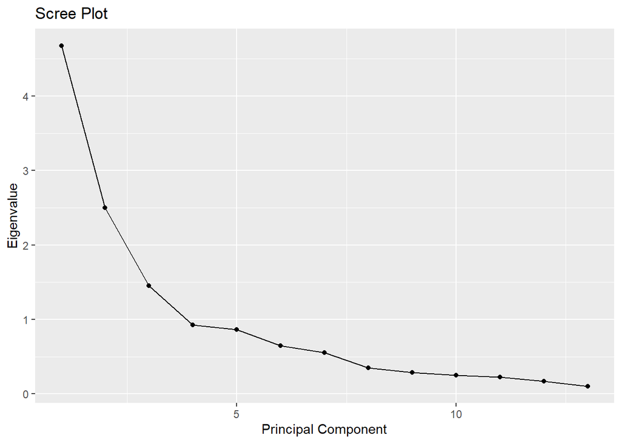

```r
eigenvalues <- eigen(cov(wine_data))$values
df <- data.frame(PC = 1:length(eigenvalues), Eigenvalue = eigenvalues)
ggplot(df, aes(x = PC, y = Eigenvalue)) +
  geom_point() +
  geom_line() +
  labs(x = "Principal Component", y = "Eigenvalue") +
  ggtitle("Scree Plot")
```

```r
(round(eigenvalues, 2))
```

```
##  [1] 4.68 2.50 1.45 0.92 0.86 0.64 0.55 0.35 0.29 0.25 0.23 0.17 0.10
```

```r
(round((sum(eigenvalues[1:4]) / sum(eigenvalues))*100,2))
```

```
## [1] 73.51
```

$73.51 \%$ of the total variation is contributed by the first $4$ principal components as confirmed by the screeplot where the elbow appears.

```r
eigenvectors <- as.data.frame(eigen(cov(wine_data))$vectors)
eigenvectors <- eigenvectors[,1:4]

rownames(eigenvectors) <- c("Alcohol", "Malic", "Ash", "Alcalinity", "Magnesium", "Phenols", "Flavanoids", "Nonflavanoid", "Proanthocyanins", "ColorIntensity", "Hue", "OD280_OD315", "Proline")
colnames(eigenvectors) <- c("e1", "e2", "e3", "e4")
kable(eigenvectors)
```

|  | e1 | e2 | e3 | e4 |
| --- | --- | --- | --- | --- |
| Alcohol | -0.1378881 | -0.4858346 | -0.2087749 | 0.0011407 |
| Malic | 0.2463811 | -0.2215748 | 0.0901933 | -0.5331364 |
| Ash | 0.0043183 | -0.3152819 | 0.6237430 | 0.2053483 |
| Alcalinity | 0.2373796 | 0.0121435 | 0.6137987 | -0.0572236 |
| Magnesium | -0.1350017 | -0.3002883 | 0.1357316 | 0.3916939 |
| Phenols | -0.3958694 | -0.0705490 | 0.1446205 | -0.2025993 |
| Flavanoids | -0.4243942 | -0.0017321 | 0.1493175 | -0.1555752 |
| Nonflavanoid | 0.2991357 | -0.0246692 | 0.1691363 | 0.1753302 |
| Proanthocyanins | -0.3128032 | -0.0414456 | 0.1506018 | -0.3917438 |
| ColorIntensity | 0.0932856 | -0.5280188 | -0.1360832 | -0.0723711 |
| Hue | -0.2995654 | 0.2740507 | 0.0825512 | 0.4194314 |
| OD280_OD315 | -0.3772025 | 0.1654491 | 0.1668111 | -0.1904646 |
| Proline | -0.2842810 | -0.3695384 | -0.1280343 | 0.2236218 |

Recall our principal components are of the form:

$$Y_i = e_i'X$$

Essentially, we have reduced the original data set from the original $13$ predictors to a new set of $4$ uncorrelated linear combinations of our original predictors. These new principal components could be used as predictors instead in a multiple linear regression setting for predicting the `class` variable.

Aeberhard, Stefan, and M. Forina. 1991. “Wine.”

Alin, Aylin. 2010. “Multicollinearity: Multicollinearity.” *Wiley Interdisciplinary Reviews: Computational Statistics* 2 (3): 370–74. https://doi.org/10.1002/wics.84.

Johnson, Richard A., and Dean W. Wichern. 2007. *Applied Multivariate Statistical Analysis*. 6th ed. Upper Saddle River, N.J: Pearson Prentice Hall.